# Mortality and Lifestyle in the US related to Cardiovascular diseases

Diego Reyes, Isaiah Vaughnn, James Tweedle

12/2/2019

## Has the average mortality rate from Cardiovascular Disease in the United States increased/decreased from 2000-2017?

As seen in the graph below, mortality for multiple groups(age,sex,race) from cardiovascular disease is trending down from 2000-2017. This is likely due to the great strides seen in the field of medicine over the past 20 years. Better medicine, more evidence-based approaches, etc have all contributed to this downtrend.

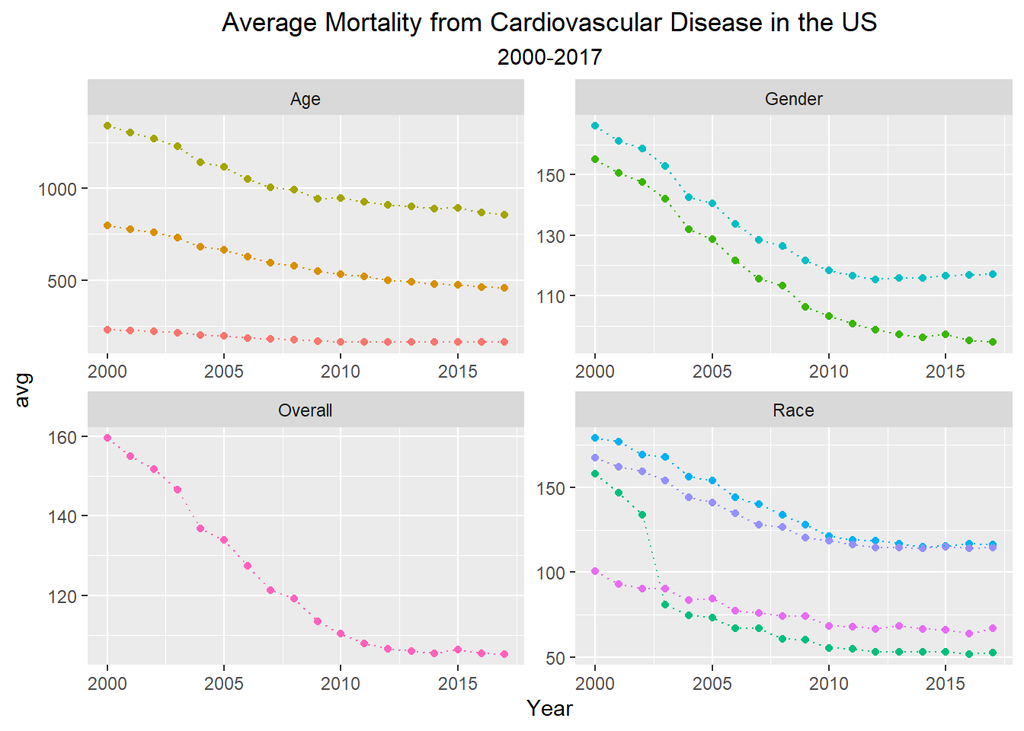

## Which states have the highest average mortality from various Cardiovascular diseases?

The most interesting conclusion about the below graph is what I would call “repeat offenders.” There are several states making it into the top 5 for multiple Cardiovascular disease states. North Dakota is number one in three of the six states. Mississippi, Arkansas, West Virginia, and even DC show up multiple times in the top 5 states.

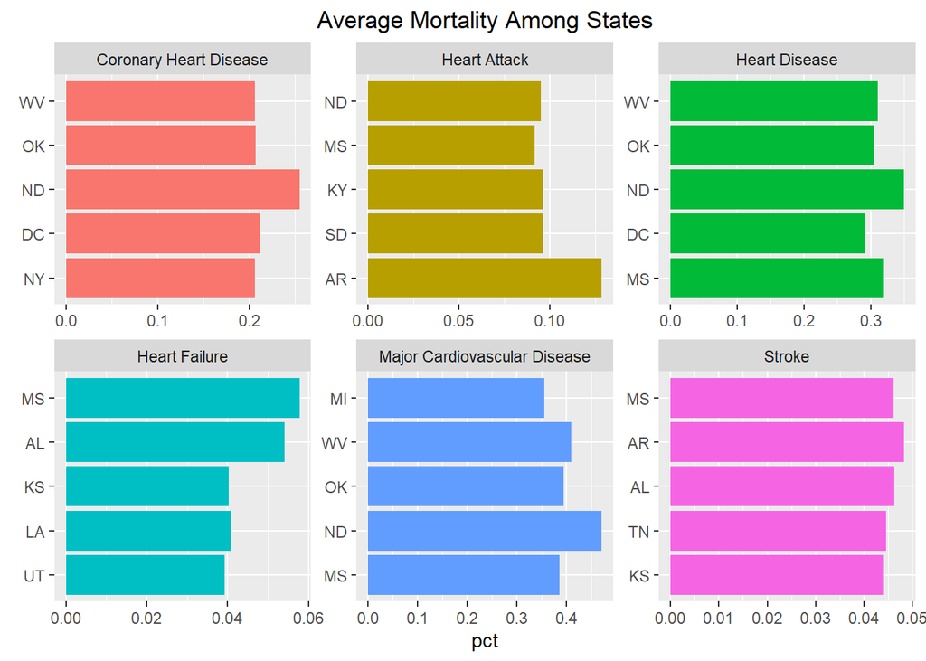

## Which gender has the highest average mortality from various Cardiovascular diseases?

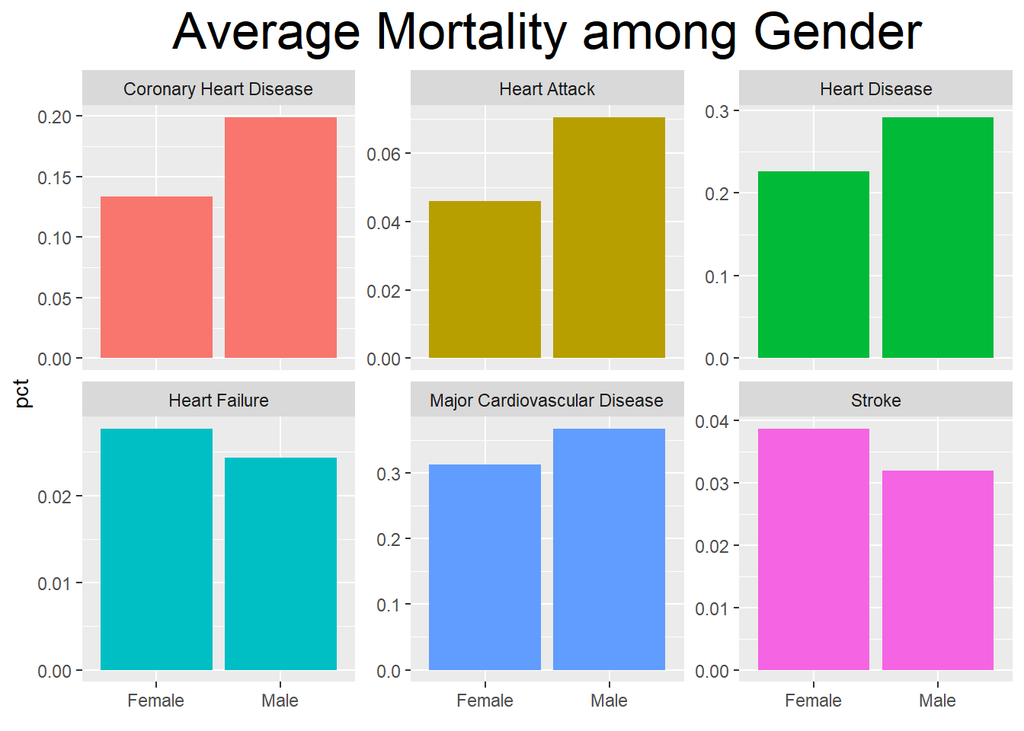

### What is the mortality among states due to Cardiovascular diseases?

In this map we can see how the southern states of the US are more affected by cardiovascular diseases, probably because of food or lifestyle. From our dataset we can see that, unfortunately Mississippi, has the highest mortality rate for cardiovascular diseases with 160 per 100,000 population. The state with the lowest cardiovascular mortality rate is Alaska with a rate of 80 per 100,000

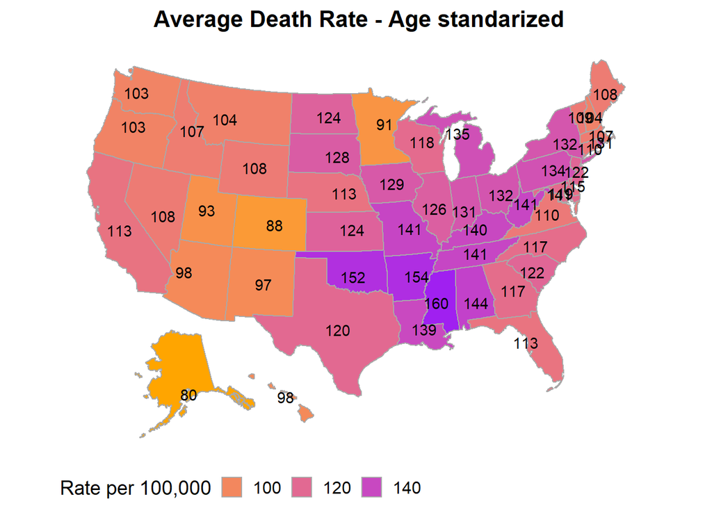

## From what county does the data for Mississippi comes from and what is the average mortality rate there?

The county is Leake county with a mortality rate of 160 per 100,000

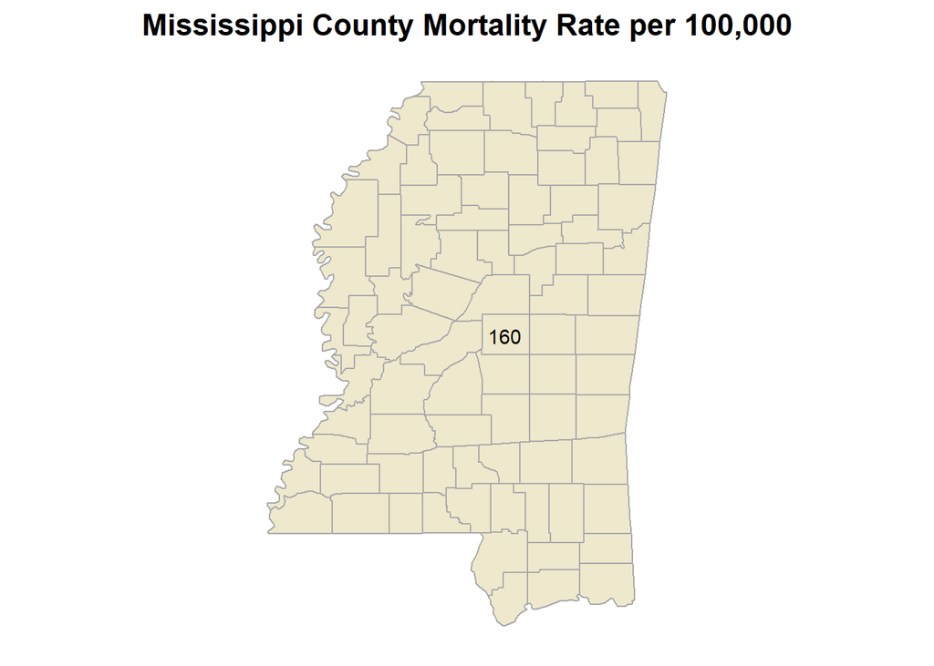

## What is the relationship between age groups, life styles, Cardiovascular disease and death rates?

As we can see on the graph there is a significant increase in the percent of people with cardiovascular disease for the second age group, and a similar trend can be seen for the mortality rate. While there is a decrease in activity from the first to second age group, it is a very small change compared to the others. It can be interpreted as that there might be other relevant factors that impact cardiovascular diseases and death rates rather than only activity.

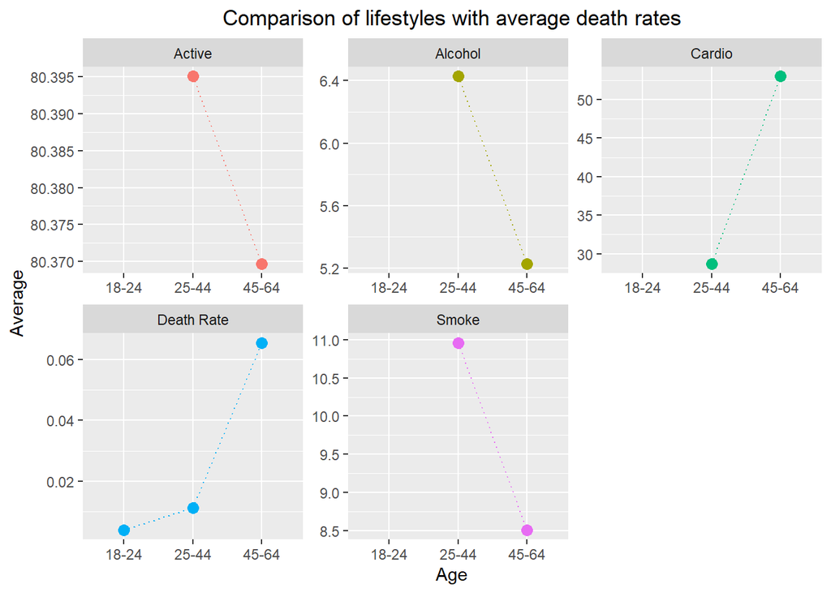

## What is the average mortality by state?

Rates are expressed as per 100,000 population. We wanted to display the different topics or diseases analyzed in the dataset to compare the mortality rates by topic for each state. With a leaflet map we were able to add labels to each state to show the mortality rates per topic in an interactive map.

[interactive chart not shown]

## What are lifestyle percentages by gender, and what factors affect Cardiovascular disease incidence?

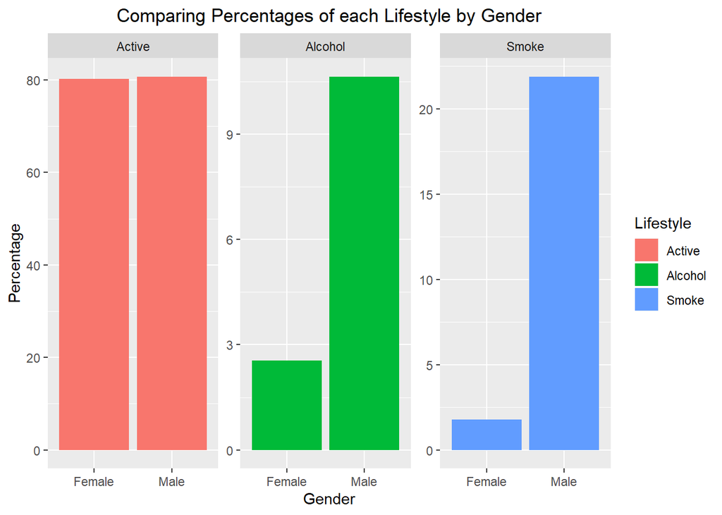

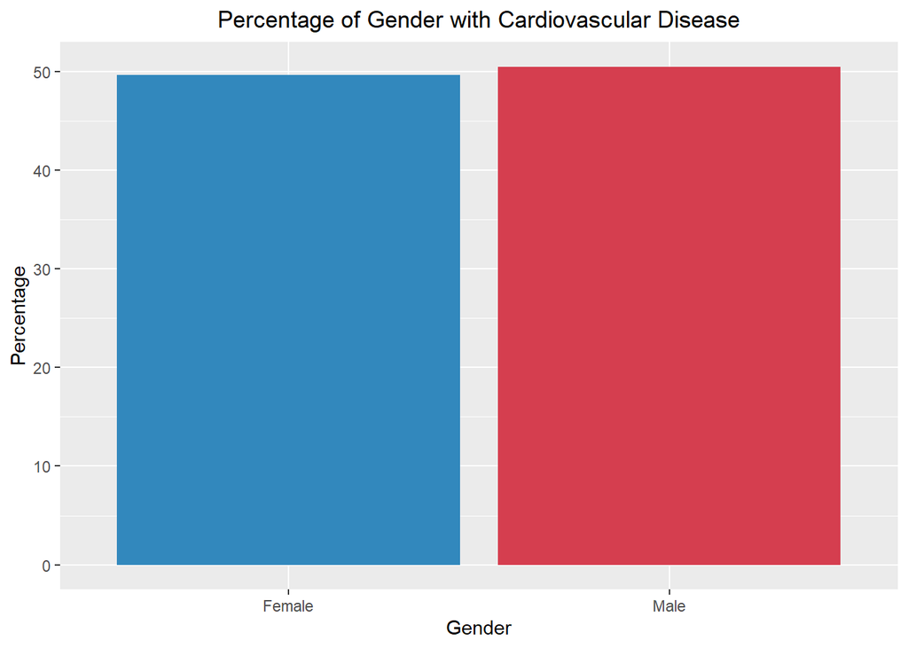

## Distributions of Lifestyles with Cardiovascular Disease

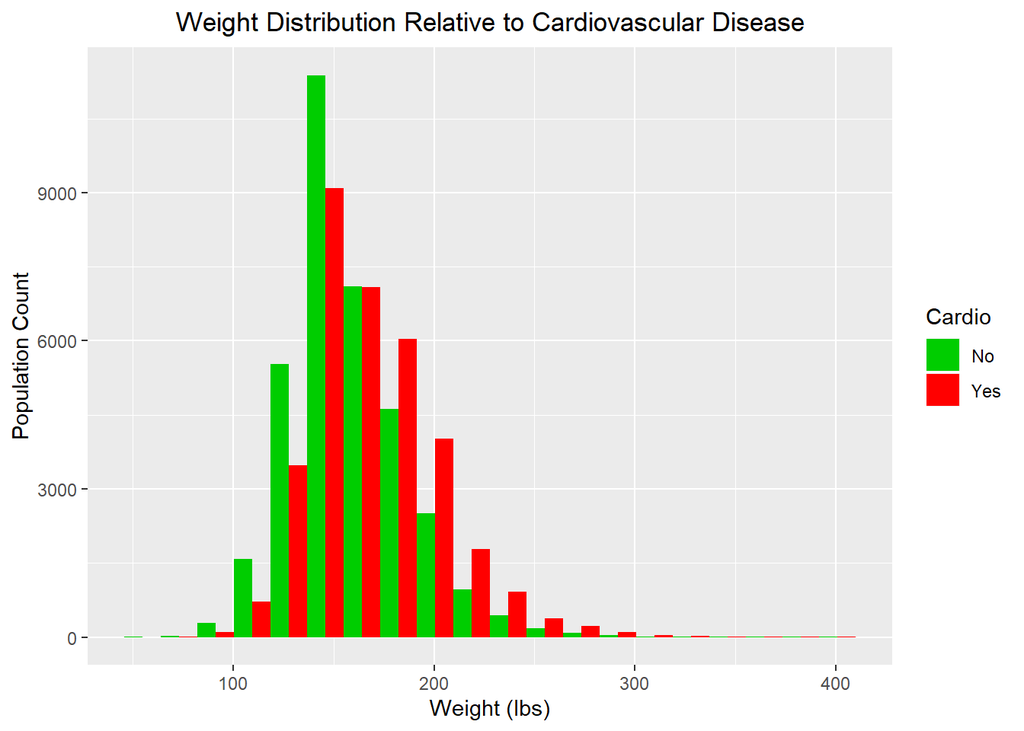

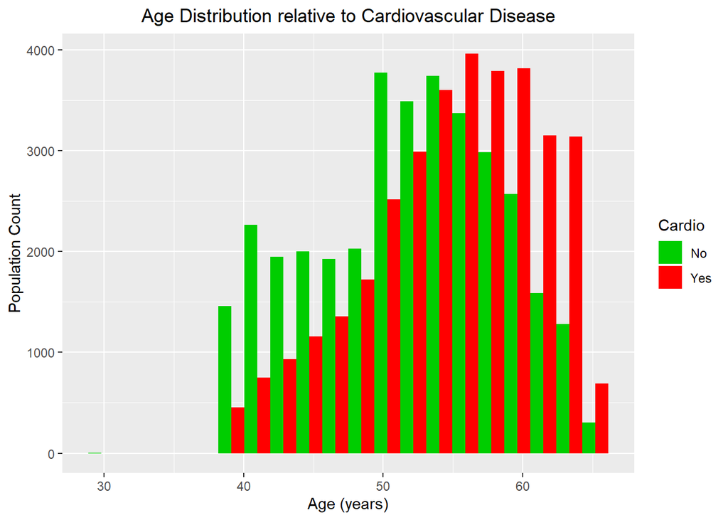

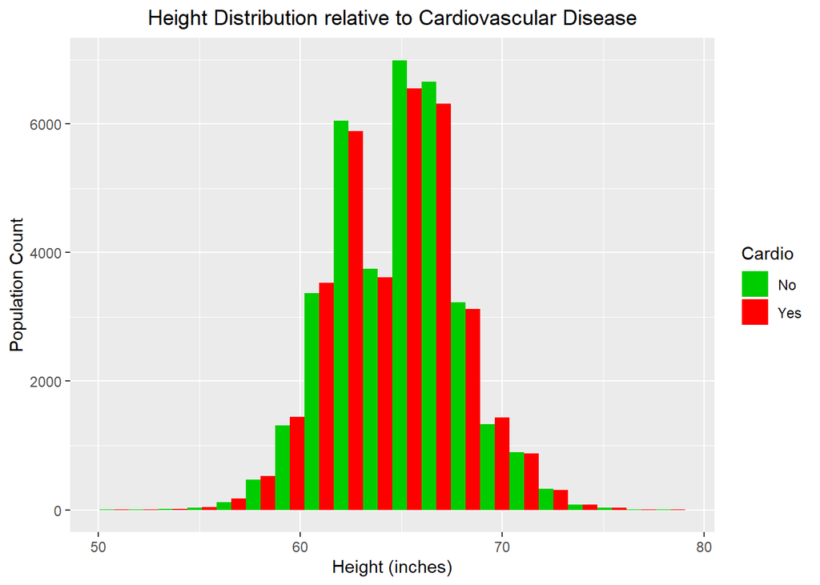

## How are systolic and diastolic blood pressure indicators of Cardiovascular Disease?

Both systolic and diastolic blood pressure seem to affect cardiovascular disease incidence. Systolic blood pressure is more of an indicator of disease than diastolic blood pressure. After a systolic blood pressure of 130 mmHg cardiovascular disease increases in rate. After 100 mmHg for diastolic blood pressure cardiovascular disease also increases in rate.

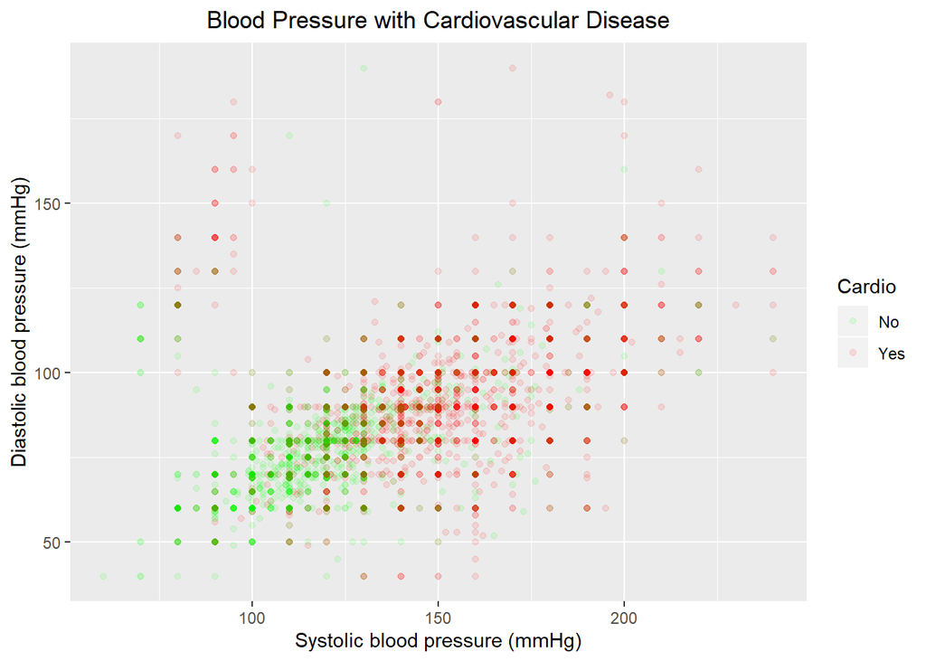

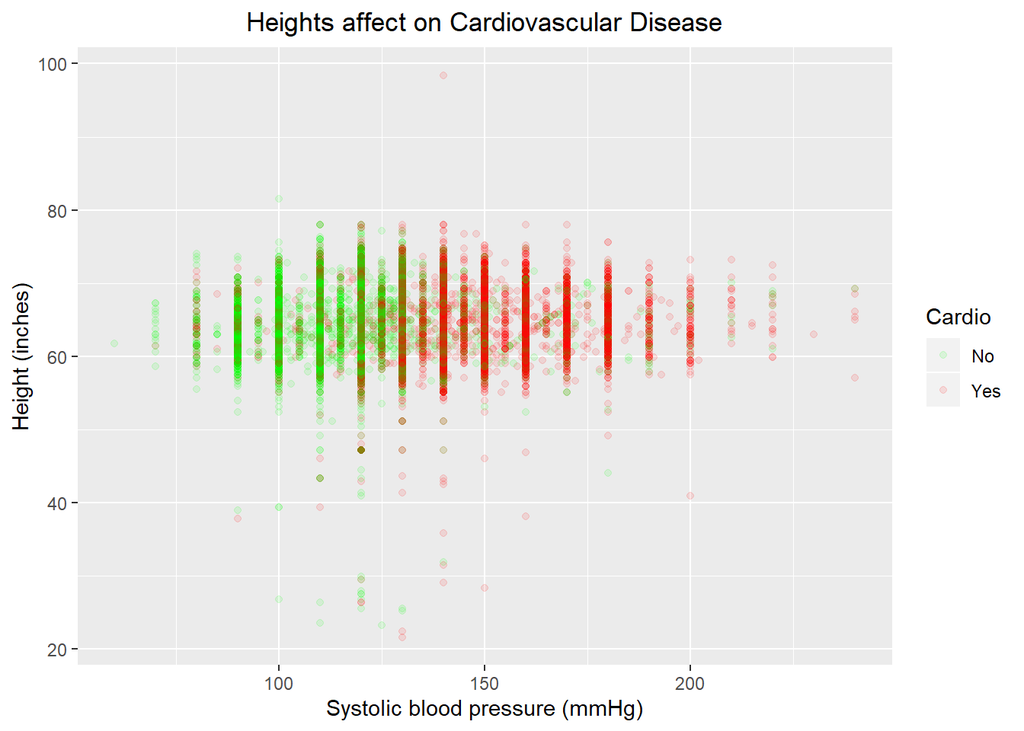

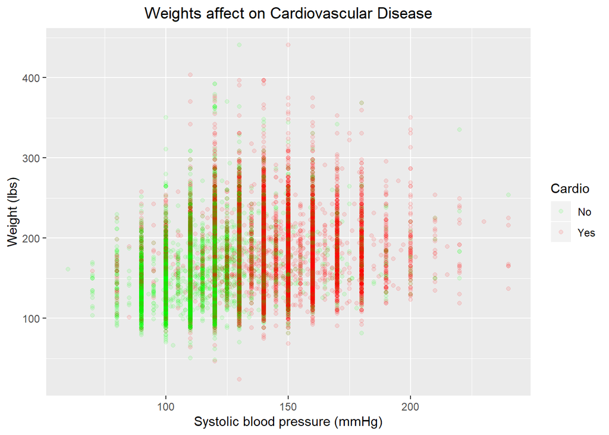

Conclusion: Both systolic and diastolic blood pressure seem to affect cardiovascular disease incidence. Systolic blood pressure is more of an indicator of disease than diastolic blood pressure. Height does not seem to affect presence of disease while weight weakly affects presence of disease.